# COVID-19 Dataset Analysis: Case Fatality Rates and Regional Trends

Kelvin Khuu

## Question of Interest

**How do case fatality rates (CFR) differ across regions over time, and can we predict mortality rates based on cumulative cases?**

This analysis examines COVID-19 data from multiple countries to understand the relationship between infection rates and mortality, identify temporal trends in case fatality rates, and explore whether early case numbers can predict later mortality patterns.

## Description of Data

The dataset originates from the Johns Hopkins University Center for Systems Science and Engineering (CSSE) COVID-19 Data Repository. This repository contains daily time series data tracking confirmed cases and deaths globally from January 22, 2020, through March 10, 2023, when collection ceased.

**Data Source:** https://github.com/CSSEGISandData/COVID-19

The dataset includes: - Daily cumulative confirmed cases by country/region - Daily cumulative deaths by country/region - Geographic information (Province/State and Country/Region) - Time series data spanning over three years of the pandemic

## Import Libraries

```r
library(tidyverse)
library(lubridate)
library(ggplot2)
library(scales)
library(broom)
```

## Import the Data

```r
# GitHub repository base URL
url_in <- "https://raw.githubusercontent.com/CSSEGISandData/COVID-19/master/csse_covid_19_data/csse_covid_19_time_series/"

# CSV file names
file_names <- c("time_series_covid19_confirmed_global.csv",
                "time_series_covid19_deaths_global.csv")

# Concatenate to create full URLs
urls <- str_c(url_in, file_names)

# Read in the data
global_cases <- read_csv(urls[1])
global_deaths <- read_csv(urls[2])
```

```r
# Preview the structure of raw data
head(global_cases, 3)
```

```
## # A tibble: 3 × 1,147
##   `Province/State` `Country/Region`   Lat  Long `1/22/20` `1/23/20` `1/24/20`
##   <chr>            <chr>            <dbl> <dbl>     <dbl>     <dbl>     <dbl>
## 1 <NA>             Afghanistan       33.9 67.7          0         0         0
## 2 <NA>             Albania           41.2 20.2          0         0         0
## 3 <NA>             Algeria           28.0  1.66         0         0         0
## # ℹ 1,140 more variables: `1/25/20` <dbl>, `1/26/20` <dbl>, `1/27/20` <dbl>,
## #   `1/28/20` <dbl>, `1/29/20` <dbl>, `1/30/20` <dbl>, `1/31/20` <dbl>,
## #   `2/1/20` <dbl>, `2/2/20` <dbl>, `2/3/20` <dbl>, `2/4/20` <dbl>,
## #   `2/5/20` <dbl>, `2/6/20` <dbl>, `2/7/20` <dbl>, `2/8/20` <dbl>,
## #   `2/9/20` <dbl>, `2/10/20` <dbl>, `2/11/20` <dbl>, `2/12/20` <dbl>,
## #   `2/13/20` <dbl>, `2/14/20` <dbl>, `2/15/20` <dbl>, `2/16/20` <dbl>,
## #   `2/17/20` <dbl>, `2/18/20` <dbl>, `2/19/20` <dbl>, `2/20/20` <dbl>, …
```

```r
head(global_deaths, 3)
```

```
## # A tibble: 3 × 1,147
##   `Province/State` `Country/Region`   Lat  Long `1/22/20` `1/23/20` `1/24/20`
##   <chr>            <chr>            <dbl> <dbl>     <dbl>     <dbl>     <dbl>
## 1 <NA>             Afghanistan       33.9 67.7          0         0         0
## 2 <NA>             Albania           41.2 20.2          0         0         0
## 3 <NA>             Algeria           28.0  1.66         0         0         0
## # ℹ 1,140 more variables: `1/25/20` <dbl>, `1/26/20` <dbl>, `1/27/20` <dbl>,
## #   `1/28/20` <dbl>, `1/29/20` <dbl>, `1/30/20` <dbl>, `1/31/20` <dbl>,
## #   `2/1/20` <dbl>, `2/2/20` <dbl>, `2/3/20` <dbl>, `2/4/20` <dbl>,
## #   `2/5/20` <dbl>, `2/6/20` <dbl>, `2/7/20` <dbl>, `2/8/20` <dbl>,
## #   `2/9/20` <dbl>, `2/10/20` <dbl>, `2/11/20` <dbl>, `2/12/20` <dbl>,
## #   `2/13/20` <dbl>, `2/14/20` <dbl>, `2/15/20` <dbl>, `2/16/20` <dbl>,
## #   `2/17/20` <dbl>, `2/18/20` <dbl>, `2/19/20` <dbl>, `2/20/20` <dbl>, …
```

## Tidy and Transform Data

```r
# Transform cases data from wide to long format
covid_cases <- global_cases %>%
  pivot_longer(cols = -c(`Province/State`, `Country/Region`, Lat, Long),
               names_to = "date",
               values_to = "cumulative_cases") %>%
  select(-Lat, -Long) %>%
  mutate(date = mdy(date)) %>%
  rename(State = `Province/State`, Country = `Country/Region`)

# Transform deaths data from wide to long format
covid_deaths <- global_deaths %>%
  pivot_longer(cols = -c(`Province/State`, `Country/Region`, Lat, Long),
               names_to = "date",
               values_to = "cumulative_deaths") %>%
  select(-Lat, -Long) %>%
  mutate(date = mdy(date)) %>%
  rename(State = `Province/State`, Country = `Country/Region`)

# Merge cases and deaths
covid_data <- covid_cases %>%
  left_join(covid_deaths, by = c("State", "Country", "date"))

# Aggregate by country (sum all provinces/states)
covid_country <- covid_data %>%
  group_by(Country, date) %>%
  summarise(
    total_cases = sum(cumulative_cases, na.rm = TRUE),
    total_deaths = sum(cumulative_deaths, na.rm = TRUE),
    .groups = "drop"
  ) %>%
  mutate(
    case_fatality_rate = ifelse(total_cases > 0,
                                  (total_deaths / total_cases) * 100,
                                  0)
  )

head(covid_country)
```

```
## # A tibble: 6 × 5
##   Country     date       total_cases total_deaths case_fatality_rate
##   <chr>       <date>           <dbl>        <dbl>              <dbl>
## 1 Afghanistan 2020-01-22           0            0                  0
## 2 Afghanistan 2020-01-23           0            0                  0
## 3 Afghanistan 2020-01-24           0            0                  0
## 4 Afghanistan 2020-01-25           0            0                  0
## 5 Afghanistan 2020-01-26           0            0                  0
## 6 Afghanistan 2020-01-27           0            0                  0
```

## Select Countries for Analysis

```r
# Select diverse countries with substantial case numbers
countries_of_interest <- c("US", "Brazil", "India", "United Kingdom", "Japan")

covid_selected <- covid_country %>%
  filter(Country %in% countries_of_interest)

# Calculate new daily cases and deaths
covid_selected <- covid_selected %>%
  group_by(Country) %>%
  arrange(date) %>%
  mutate(
    new_cases = total_cases - lag(total_cases, default = 0),
    new_deaths = total_deaths - lag(total_deaths, default = 0)
  ) %>%
  ungroup()

summary(covid_selected)
```

```
##    Country               date             total_cases         total_deaths
##  Length:5715        Min.   :2020-01-22   Min.   :        0   Min.   :      0
##  Class :character   1st Qu.:2020-11-02   1st Qu.:  1710866   1st Qu.:  33913
##  Mode  :character   Median :2021-08-15   Median : 13950997   Median : 179934
##                     Mean   :2021-08-15   Mean   : 21624406   Mean   : 306245
##                     3rd Qu.:2022-05-28   3rd Qu.: 33318596   3rd Qu.: 530643
##                     Max.   :2023-03-09   Max.   :103802702   Max.   :1123836
##  case_fatality_rate   new_cases         new_deaths
##  Min.   :  0.000    Min.   : -19796   Min.   :-256.0
##  1st Qu.:  1.153    1st Qu.:   1780   1st Qu.:  30.0
##  Median :  1.692    Median :  18696   Median : 146.0
##  Mean   :  2.573    Mean   :  42616   Mean   : 463.3
##  3rd Qu.:  2.779    3rd Qu.:  50325   3rd Qu.: 585.5
##  Max.   :100.000    Max.   :1354505   Max.   :7374.0
```

## Visualization 1: Case Fatality Rate Over Time

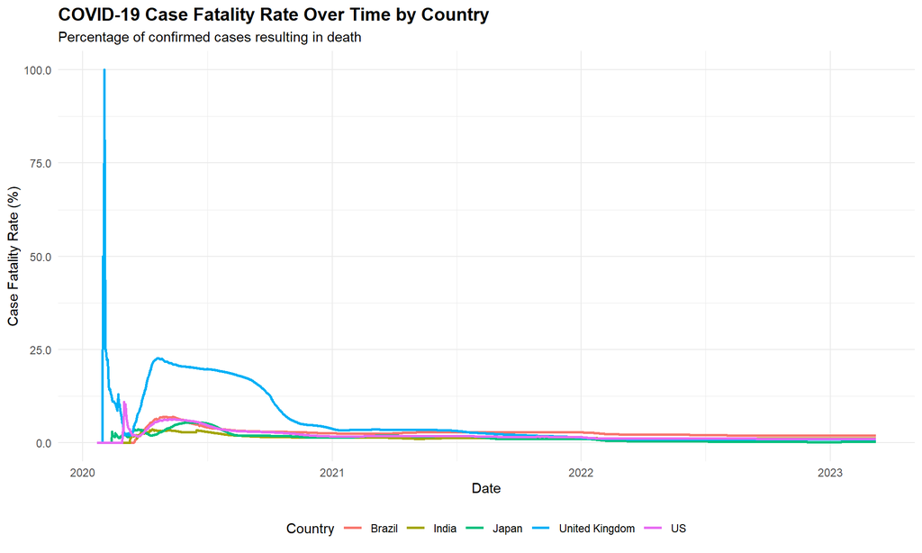

```r
ggplot(covid_selected, aes(x = date, y = case_fatality_rate, color = Country)) +
  geom_line(linewidth = 1) +
  labs(
    title = "COVID-19 Case Fatality Rate Over Time by Country",
    subtitle = "Percentage of confirmed cases resulting in death",
    x = "Date",
    y = "Case Fatality Rate (%)",
    color = "Country"
  ) +
  scale_y_continuous(labels = scales::number_format(accuracy = 0.1)) +
  theme_minimal() +
  theme(
    plot.title = element_text(size = 14, face = "bold"),
    legend.position = "bottom"
  )
```

**Interpretation:** This visualization shows how case fatality rates evolved differently across countries. Early in the pandemic, CFR was highly volatile due to limited testing. As testing expanded and treatments improved, CFR generally declined. Notable differences between countries likely reflect healthcare system capacity, demographic factors, and reporting accuracy.

## Visualization 2: Total Deaths vs Total Cases (Log Scale)

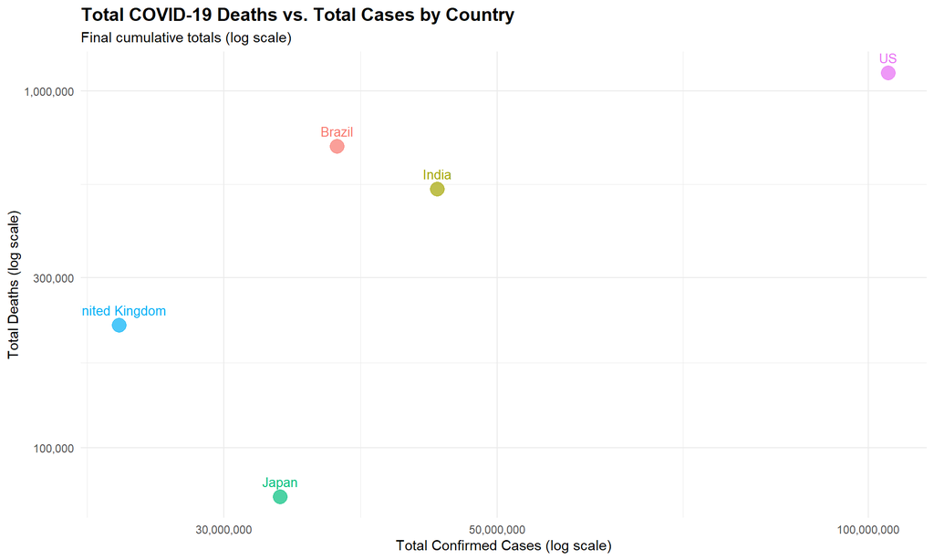

```r
# Get the latest data point for each country
covid_latest <- covid_selected %>%
  group_by(Country) %>%
  filter(date == max(date)) %>%
  ungroup()

ggplot(covid_latest, aes(x = total_cases, y = total_deaths, color = Country)) +
  geom_point(size = 5, alpha = 0.7) +
  geom_text(aes(label = Country), vjust = -1, size = 3.5) +
  scale_x_log10(labels = scales::comma) +
  scale_y_log10(labels = scales::comma) +
  labs(
    title = "Total COVID-19 Deaths vs. Total Cases by Country",
    subtitle = "Final cumulative totals (log scale)",
    x = "Total Confirmed Cases (log scale)",
    y = "Total Deaths (log scale)",
    color = "Country"
  ) +
  theme_minimal() +
  theme(
    plot.title = element_text(size = 14, face = "bold"),
    legend.position = "none"
  )
```

**Interpretation:** On a logarithmic scale, countries falling on similar diagonal lines have comparable case fatality rates. Countries above the line experienced higher mortality relative to cases, while those below had lower mortality rates. This can reflect differences in healthcare quality, age demographics, testing availability, and reporting practices.

## Visualization 3: Daily New Cases and Deaths Comparison

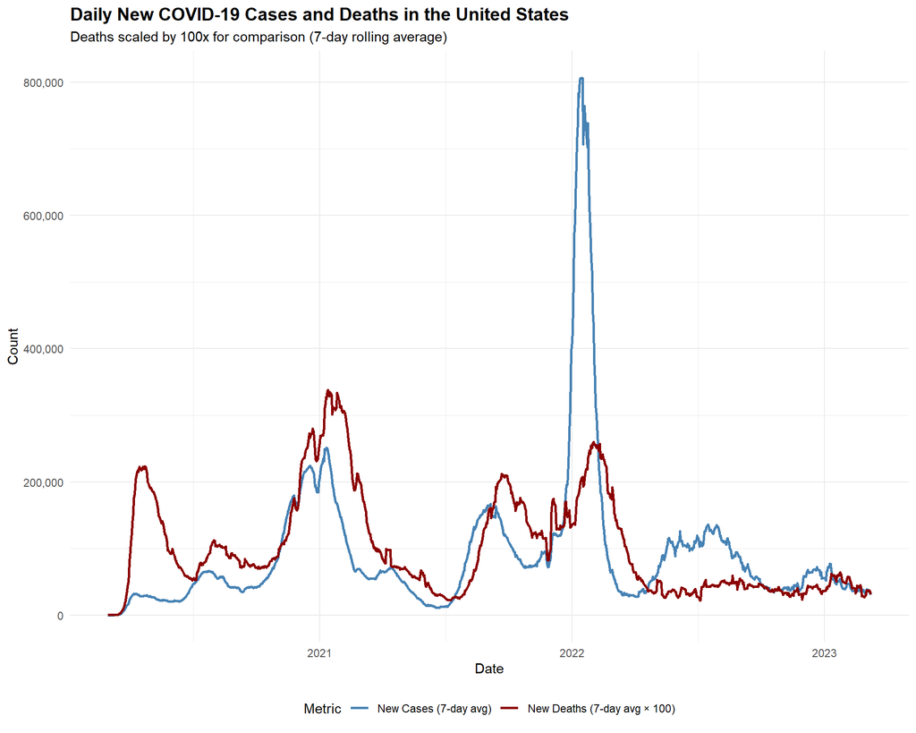

```r
# Calculate 7-day rolling averages to smooth data
covid_selected_smooth <- covid_selected %>%
  group_by(Country) %>%
  arrange(date) %>%
  mutate(
    cases_7day_avg = zoo::rollmean(new_cases, k = 7, fill = NA, align = "right"),
    deaths_7day_avg = zoo::rollmean(new_deaths, k = 7, fill = NA, align = "right")
  ) %>%
  ungroup()

# Focus on one country for detailed view
us_data <- covid_selected_smooth %>%
  filter(Country == "US", date >= as.Date("2020-03-01"))

ggplot(us_data, aes(x = date)) +
  geom_line(aes(y = cases_7day_avg, color = "New Cases (7-day avg)"), linewidth = 1) +
  geom_line(aes(y = deaths_7day_avg * 100, color = "New Deaths (7-day avg × 100)"), linewidth = 1) +
  labs(
    title = "Daily New COVID-19 Cases and Deaths in the United States",
    subtitle = "Deaths scaled by 100x for comparison (7-day rolling average)",
    x = "Date",
    y = "Count",
    color = "Metric"
  ) +
  scale_y_continuous(labels = scales::comma) +
  scale_color_manual(values = c("New Cases (7-day avg)" = "steelblue",
                                 "New Deaths (7-day avg × 100)" = "darkred")) +
  theme_minimal() +
  theme(
    plot.title = element_text(size = 14, face = "bold"),
    legend.position = "bottom"
  )
```

## Statistical Model: Predicting Case Fatality Rate

```r
# Prepare data for modeling (filter to later period with more stable testing)
model_data <- covid_selected %>%
  filter(date >= as.Date("2021-01-01"), total_cases >= 1000) %>%
  mutate(
    log_cases = log10(total_cases + 1),
    log_deaths = log10(total_deaths + 1)
  )

# Linear model: log(deaths) as a function of log(cases) and country
cfr_model <- lm(log_deaths ~ log_cases + Country, data = model_data)

summary(cfr_model)
```

```
##
## Call:
## lm(formula = log_deaths ~ log_cases + Country, data = model_data)
##
## Residuals:
##      Min       1Q   Median       3Q      Max
## -0.25276 -0.04063  0.02005  0.04993  0.13307
##
## Coefficients:
##                        Estimate Std. Error  t value Pr(>|t|)
## (Intercept)            2.339951   0.023714   98.673  < 2e-16 ***
## log_cases              0.461464   0.003198  144.315  < 2e-16 ***
## CountryIndia          -0.196556   0.003671  -53.545  < 2e-16 ***
## CountryJapan          -1.019880   0.004479 -227.689  < 2e-16 ***
## CountryUnited Kingdom -0.351980   0.003765  -93.498  < 2e-16 ***
## CountryUS             -0.019752   0.003856   -5.122 3.16e-07 ***
## ---
## Signif. codes:  0 '***' 0.001 '**' 0.01 '*' 0.05 '.' 0.1 ' ' 1
##
## Residual standard error: 0.07279 on 3984 degrees of freedom
## Multiple R-squared:  0.9845, Adjusted R-squared:  0.9845
## F-statistic: 5.062e+04 on 5 and 3984 DF,  p-value: < 2.2e-16
```

```r
# Extract model coefficients
tidy(cfr_model) %>%
  knitr::kable(digits = 4, caption = "Model Coefficients: Predicting Log Deaths")
```

Model Coefficients: Predicting Log Deaths

| term | estimate | std.error | statistic | p.value |
| --- | --- | --- | --- | --- |
| (Intercept) | 2.3400 | 0.0237 | 98.6735 | 0 |
| log_cases | 0.4615 | 0.0032 | 144.3154 | 0 |
| CountryIndia | -0.1966 | 0.0037 | -53.5445 | 0 |
| CountryJapan | -1.0199 | 0.0045 | -227.6891 | 0 |
| CountryUnited Kingdom | -0.3520 | 0.0038 | -93.4979 | 0 |
| CountryUS | -0.0198 | 0.0039 | -5.1222 | 0 |

## Analysis: Peak Case Fatality Rates by Country

```r
# Find peak CFR for each country
peak_cfr <- covid_selected %>%
  filter(total_cases >= 10000) %>%  # Only consider after substantial spread
  group_by(Country) %>%
  summarise(
    max_cfr = max(case_fatality_rate, na.rm = TRUE),
    date_of_max = date[which.max(case_fatality_rate)],
    final_cfr = last(case_fatality_rate),
    total_cases_final = last(total_cases),
    total_deaths_final = last(total_deaths)
  ) %>%
  arrange(desc(max_cfr))

knitr::kable(peak_cfr,
             digits = 2,
             caption = "Peak and Final Case Fatality Rates by Country",
             col.names = c("Country", "Peak CFR (%)", "Date of Peak",
                          "Final CFR (%)", "Total Cases", "Total Deaths"))
```

Peak and Final Case Fatality Rates by Country

| Country | Peak CFR (%) | Date of Peak | Final CFR (%) | Total Cases | Total Deaths |
| --- | --- | --- | --- | --- | --- |
| United Kingdom | 22.65 | 2020-04-21 | 0.90 | 24658705 | 220721 |
| Brazil | 6.99 | 2020-05-12 | 1.89 | 37076053 | 699276 |
| US | 6.29 | 2020-05-15 | 1.08 | 103802702 | 1123836 |
| Japan | 5.43 | 2020-06-19 | 0.22 | 33320438 | 72997 |
| India | 3.43 | 2020-05-05 | 1.19 | 44690738 | 530779 |

**Analysis Findings:**

Looking at the peak CFR data, there’s a clear pattern. Countries that hit their highest fatality rates early in 2020 were dealing with overwhelmed hospitals and limited testing. When you’re only testing the sickest patients, your death rate looks artificially high. As testing became more available and doctors figured out better treatment protocols, those rates dropped pretty dramatically across the board.

## Potential Sources of Bias

This data isn’t perfect, and there are several issues worth mentioning:

**Testing availability** varied wildly between countries. Nations with limited testing only caught severe cases, making their death rates look worse than they actually were. Meanwhile, countries doing widespread testing detected mild cases too, which brought their rates down.

**Reporting standards** weren’t consistent. Some countries counted anyone who died with COVID, others only counted deaths directly caused by COVID. There’s also the uncomfortable reality that some governments had political reasons to under report.

**Demographics matter** a country with an older population will naturally see more deaths. We didn’t adjust for age here, which is a limitation.

**Healthcare capacity** plays a huge role. More ICU beds, faster vaccine rollout, and better medical infrastructure all reduce mortality independently of how many cases you have.

## Conclusion

It’s fascinating to look back at the COVID-19 data from 2020 through 2023. What really jumps out is how the Case Fatality Rate (CFR) plummeted as the pandemic wore on, and just how much mortality varied from one country to the next. That huge drop in death rates was clearly a win for vaccinations, better medical treatments, and catching milder cases through wider testing the virus definitely got less deadly even as it kept surging in waves. The big lesson here is that places with solid healthcare systems and smart public health plans had noticeably better outcomes. Sure, we have to admit the data isn’t perfect; reporting and testing weren’t standardized across the globe. But despite those inconsistencies, the main conclusion holds: good public health measures really do make a measurable difference when it matters most.